# R für Einsteiger: Musterlösungen

Kapitel 14: Varianzanalyse mit Messwiederholung

*Diese Musterlösung wurde erstellt von Peter Hähner (Ruhr-Universität Bochum).*

*(c) Luhmann: R fÃ¼r Einsteiger, 5. Aufl., Beltz, 2020*

## Vorbereitungen

Setzen Sie ein Arbeitsverzeichnis oder legen Sie ein entsprechendes R-Projekt an (Kap. 23).

Laden Sie dann die Datei `pruefung.RData`.

```r
load("pruefung.RData")
```

Laden Sie die benötigten Pakete (ggf. müssen Sie diese vorab noch installieren).

```r
library(psych)
library(afex)
library(emmeans)
```

## Aufgabe 1

Führen Sie eine messwiederholte Varianzanalyse mit der unabhängigen Variablen `mzp` und der abhängigen Variablen `ru` durch. Berechnen Sie auch die deskriptiven Statistiken und stellen Sie die Ergebnisse grafisch dar. Führen Sie geeignete Post-hoc-Tests durch.

```r
# Format des Datensatz prÃ¼fen
head(pruefung)
```

```
## # A tibble: 6 x 8
##      nr sex      kind  alter gruppe   mzp      gs    ru
##   <dbl> <fct>    <fct> <dbl> <fct>    <chr> <dbl> <dbl>
## 1     1 weiblich nein     27 Gruppe 1 1      3.25  1.25
## 2     1 weiblich nein     27 Gruppe 1 2      3.25  2.5
## 3     1 weiblich nein     27 Gruppe 1 3      3.25  2.5
## 4     2 mÃ¤nnlich ja       28 Gruppe 1 1      4.5   3.5
## 5     2 mÃ¤nnlich ja       28 Gruppe 1 2      4.5   4
## 6     2 mÃ¤nnlich ja       28 Gruppe 1 3      4.5   4.5
```

```r
# Deskriptive Statistiken
describeBy(pruefung$ru, pruefung$mzp, mat = TRUE)
```

```
##     item group1 vars  n     mean        sd median  trimmed      mad min max
## X11    1      1    1 96 2.554688 1.0407507   2.50 2.519231 1.297275   1   5
## X12    2      2    1 98 3.153061 0.9233739   3.25 3.175000 1.111950   1   5
## X13    3      3    1 95 4.292105 0.8232433   4.50 4.425325 0.741300   1   5
##     range       skew   kurtosis         se
## X11     4  0.2167933 -0.8909207 0.10622117
## X12     4 -0.2172961 -0.5068591 0.09327485
## X13     4 -1.4242662  2.0188297 0.08446298
```

```r
# Messwiederholte Varianzanalyse
anova.1 <- aov_car(ru ~ Error(nr/mzp), data = pruefung)
anova.1
```

```
## Anova Table (Type 3 tests)
##
## Response: ru
##   Effect           df  MSE          F  ges p.value
## 1    mzp 1.96, 180.62 0.62 115.93 *** .371   <.001
## ---
## Signif. codes:  0 '***' 0.001 '**' 0.01 '*' 0.05 '+' 0.1 ' ' 1
##
## Sphericity correction method: GG
```

Die ruhige vs.Â unruhige Stimmung verändert sich signifikant über die drei Messzeitpunkte (*F*(1.96, 180.62) = 115.93, *p* < .001, Î·<sup>2</sup> = .371).

```r
# Post-Hoc-Tests
ph.1 <- emmeans(anova.1, specs = "mzp")
pairs(ph.1)
```

```
##  contrast estimate    SE  df t.ratio p.value
##  X1 - X2    -0.605 0.114 184  -5.294 <.0001
##  X1 - X3    -1.715 0.114 184 -15.011 <.0001
##  X2 - X3    -1.110 0.114 184  -9.717 <.0001
##
## P value adjustment: tukey method for comparing a family of 3 estimates
```

Der Mittelwertsunterschied zwischen allen drei Messzeitpunkten ist signifikant (alle *p* < .001).

```
## Renaming/reordering factor levels of 'mzp':
##   X1 -> Vor der Klausur
##   X2 -> WÃ¤hrend der Klausur
##   X3 -> Nach der Klausur
```

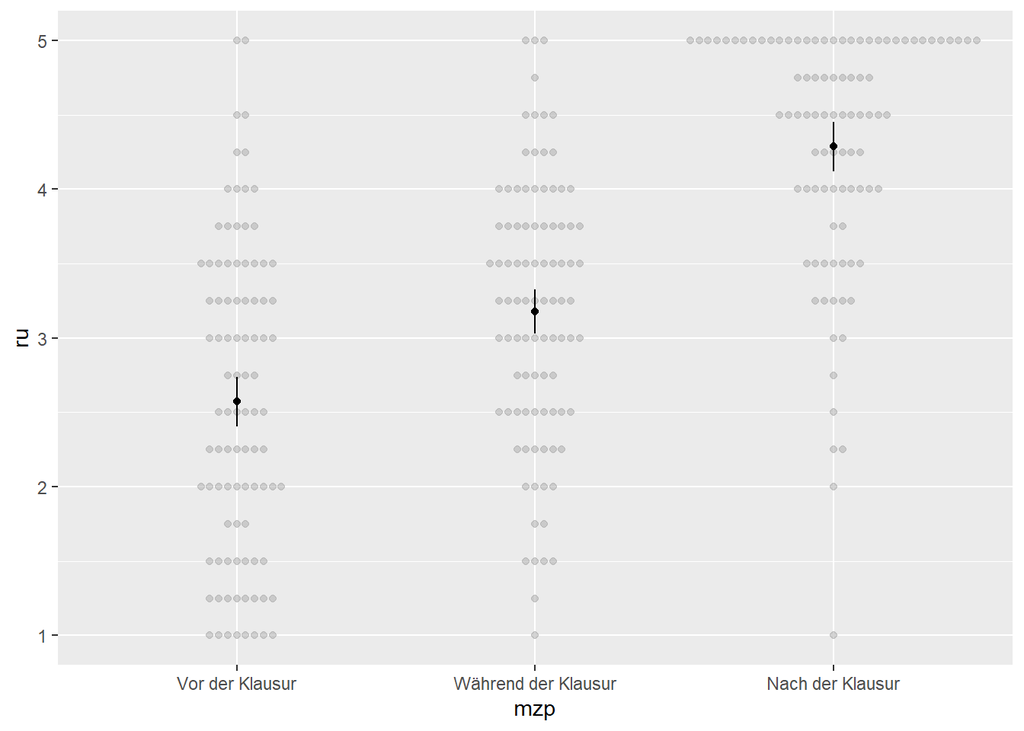

```r
# Grafische Darstellung
afex_plot(anova.1, x = "mzp", error = "within",
             factor_levels = list(
                 mzp = c("Vor der Klausur",
                         "WÃ¤hrend der Klausur",
                         "Nach der Klausur")))
```

## Aufgabe 2

Überprüfen Sie, ob sich Frauen und Männer (`sex`) darin unterscheiden, wie sich ihre ruhige vs.Â unruhige Stimmung (`ru`) über die Zeit verändert. Berechnen Sie dazu eine gemischte Varianzanalyse mit Typ-II-Quadratsummen. Berechnen Sie auch die deskriptiven Statistiken und stellen Sie die Ergebnisse grafisch dar. Führen Sie geeignete Post-Hoc-Tests durch.

```r
# Deskriptive Statistiken
describeBy(pruefung$ru, list(pruefung$mzp, pruefung$sex), mat = TRUE)
```

```
##     item group1   group2 vars  n     mean        sd median  trimmed      mad
## X11    1      1 weiblich    1 76 2.430921 0.9870821  2.250 2.399194 1.297275
## X12    2      2 weiblich    1 78 3.131410 0.9255784  3.250 3.148438 1.111950
## X13    3      3 weiblich    1 75 4.280000 0.8331802  4.500 4.409836 0.741300
## X14    4      1 mÃ¤nnlich    1 18 3.000000 1.1631600  3.250 3.000000 1.297275
## X15    5      2 mÃ¤nnlich    1 18 3.166667 0.9587062  3.250 3.187500 0.926625
## X16    6      3 mÃ¤nnlich    1 18 4.319444 0.8305099  4.625 4.406250 0.555975
##      min max range        skew   kurtosis         se
## X11 1.00   5  4.00  0.22997504 -0.8499183 0.11322609
## X12 1.00   5  4.00 -0.16589984 -0.6421742 0.10480112
## X13 1.00   5  4.00 -1.46925749  2.2628094 0.09620736
## X14 1.00   5  4.00 -0.04964456 -1.3586874 0.27415944
## X15 1.00   5  4.00 -0.23183250 -0.2966726 0.22596923
## X16 2.25   5  2.75 -1.08457925  0.1024122 0.19575307
```

```r
# Gemischte Varianzanalyse mit Typ-II-Quadratsummen
anova.2 <- aov_car(ru ~ sex + Error(nr/mzp),
                   data = pruefung, type = 2)
```

```
## Contrasts set to contr.sum for the following variables: sex
```

```r
anova.2
```

```
## Anova Table (Type 2 tests)
##
## Response: ru
##    Effect           df  MSE          F  ges p.value
## 1     sex        1, 89 1.39       1.26 .008    .265
## 2     mzp 1.97, 175.50 0.61 115.87 *** .377   <.001
## 3 sex:mzp 1.97, 175.50 0.61       2.22 .011    .112
## ---
## Signif. codes:  0 '***' 0.001 '**' 0.01 '*' 0.05 '+' 0.1 ' ' 1
##
## Sphericity correction method: GG
```

```r
# Post-Hoc-Test
ph.2 <- emmeans(anova.2, ~ mzp | sex)
pairs(ph.2)
```

```
## sex = weiblich:
##  contrast estimate    SE  df t.ratio p.value
##  X1 - X2    -0.712 0.128 178  -5.547 <.0001
##  X1 - X3    -1.825 0.128 178 -14.214 <.0001
##  X2 - X3    -1.113 0.128 178  -8.667 <.0001
##
## sex = mÃ¤nnlich:
##  contrast estimate    SE  df t.ratio p.value
##  X1 - X2    -0.167 0.259 178  -0.644 0.7957
##  X1 - X3    -1.319 0.259 178  -5.102 <.0001
##  X2 - X3    -1.153 0.259 178  -4.458 <.0001
##
## P value adjustment: tukey method for comparing a family of 3 estimates
```

Die Post-Hoc-Tests zeigen, dass sich die Stimmung bei Frauen zu allen Messzeitpunkt signifikant voneinander unterscheidet (alle *p* < .001). Bei Männern verändert sich die Stimmung vom ersten zum zweiten Messzeitpunkt hingegen nicht signifikant (*t*(178) = -0.64, *p* = .796).

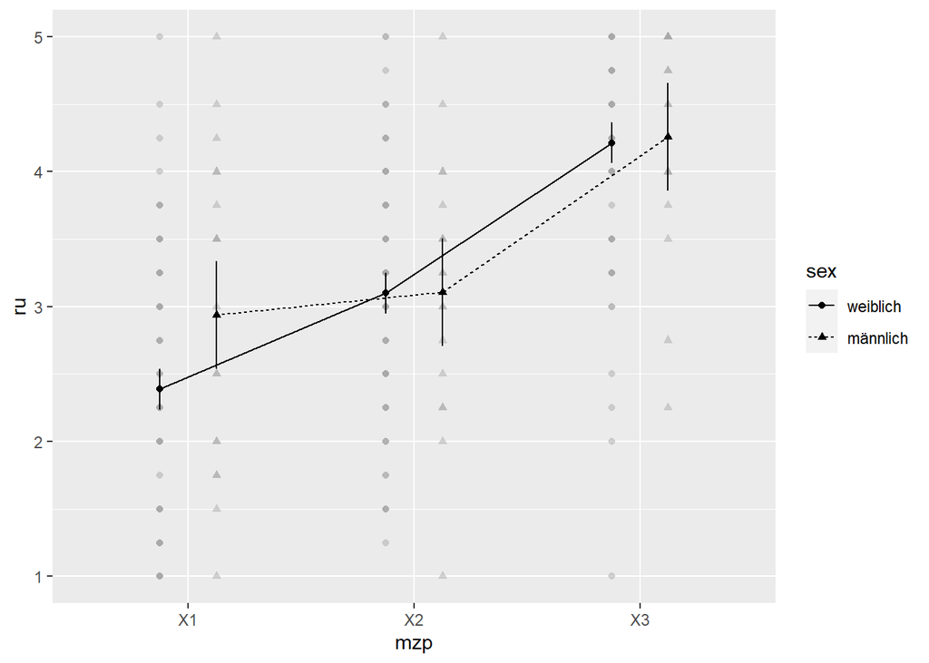

```r
# Grafische Darstellung
afex_plot(anova.2, x = "mzp", trace = "sex",
          error = "between")
```